# Fundamentals of Data Visualization

## Part II: Principles of figure design

## The principle of proportional ink

- Bars on a linear scale should always start at 0
- Be careful with log-scale (non-linear transformation)
- log-scale are more useful when comparing ratios.

## Bad

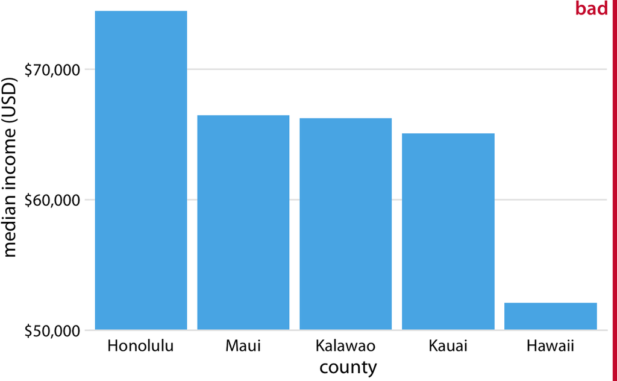

## Good

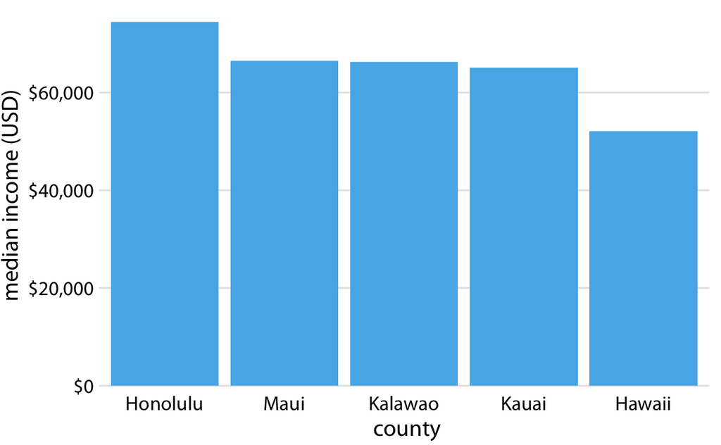

## Bad

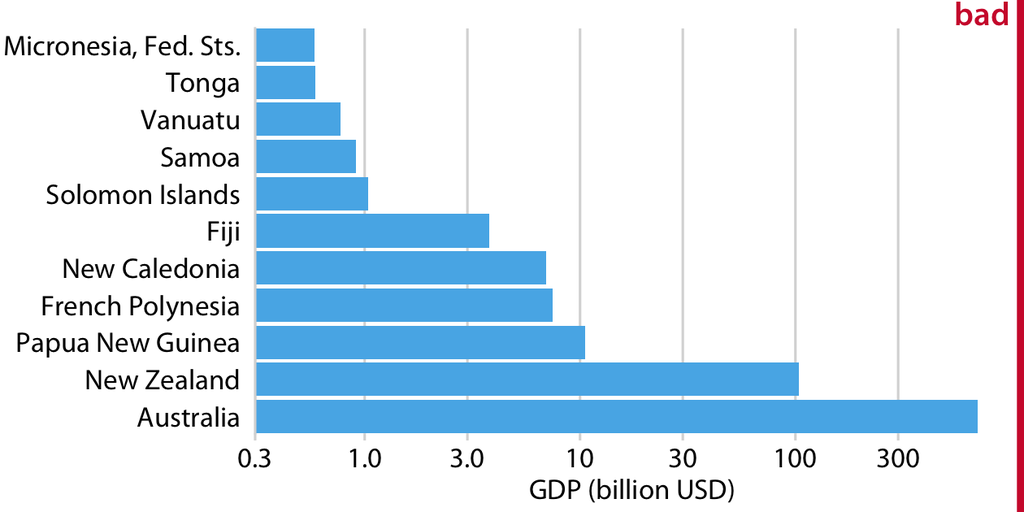

## Good

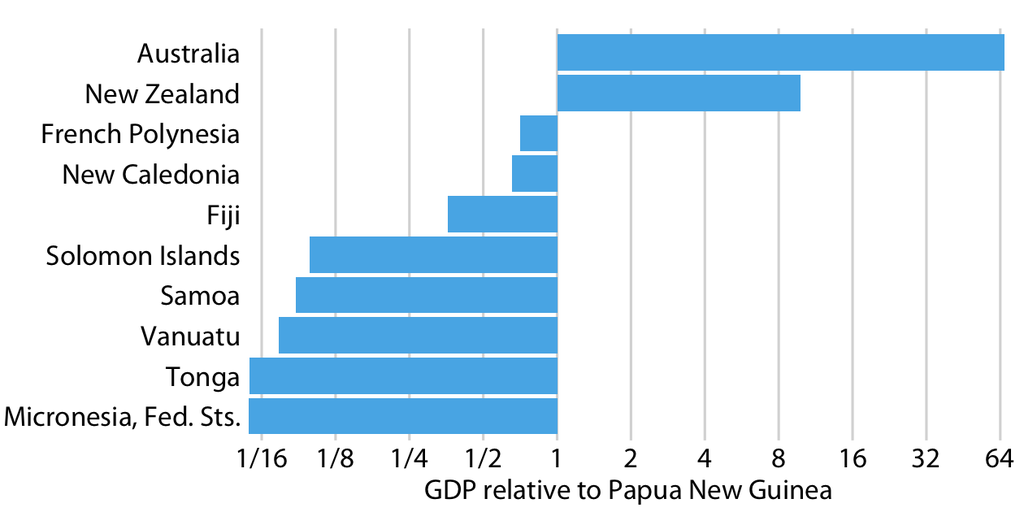

## Handling overlapping points

- Jitter points; `geom_jitter`
- One downside of jittering is that it does change the data and therefore has to be performed with care.
- If we jitter too much, we end up placing points in locations that are not representative of the underlying dataset.
- Hexagonal heatmap; `geom_hex`

## Jitter

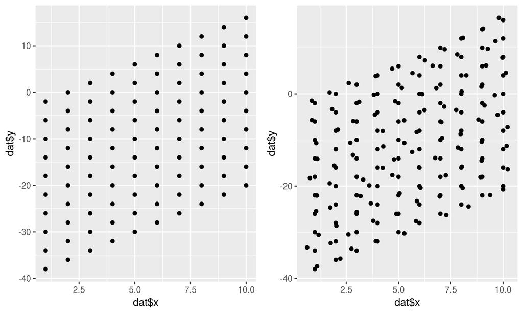

```r
> dat <- tibble(x = rep(1:10, 10),
+               y = 2 * 1:10 - 4 * rep(1:10, each = 10))
> g1 <- qplot(dat$x, dat$y)
> g2 <- qplot(dat$x, dat$y) + geom_jitter()
> grid.arrange(g1, g2, ncol = 2)
```

## Jitter

The last call added the points twice, one with `qplot` and one with `geom_jitter()`.

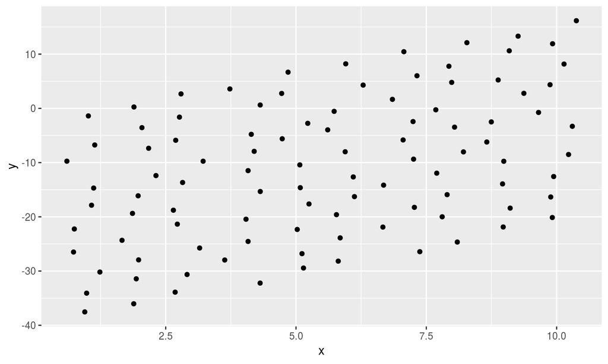

```r
> ggplot(dat, aes(x, y)) + geom_jitter()
```

## Jitter

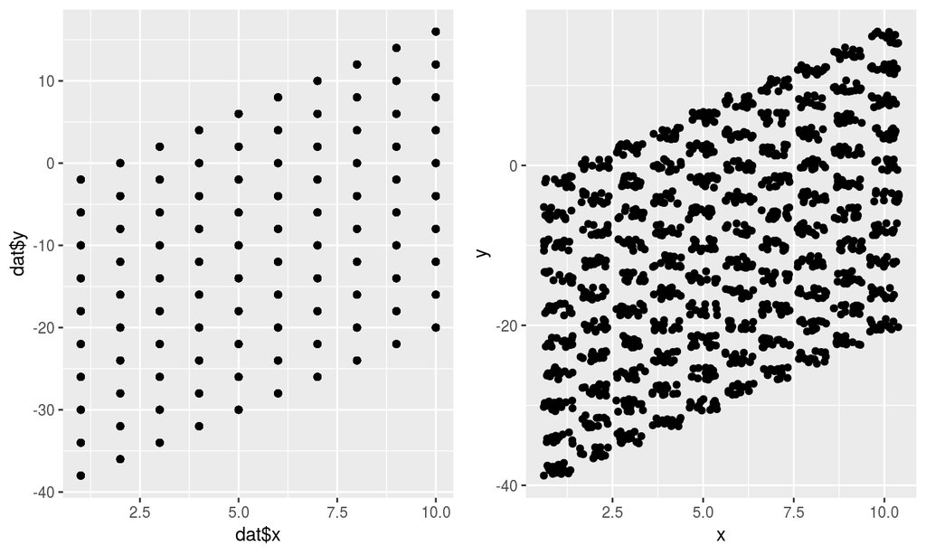

```r
> dat <- do.call(rbind, replicate(15, dat, simplify = FALSE))
> g1 <- qplot(dat$x, dat$y)
> g2 <- ggplot(dat, aes(x, y)) + geom_jitter()
> grid.arrange(g1, g2, ncol = 2)
```

## Hexagonal heatmap; better solution?

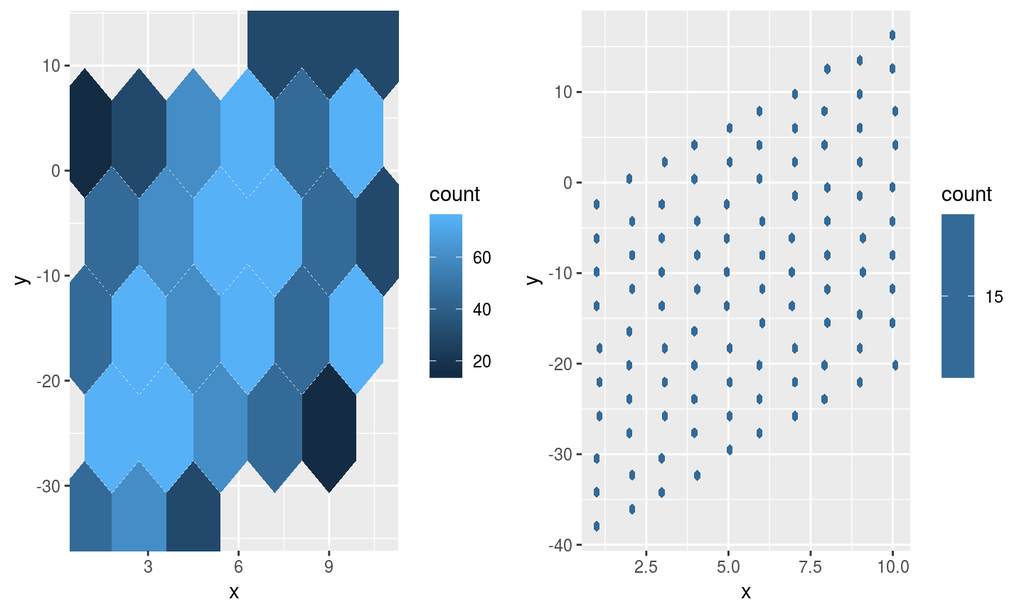

```r
> g1 <- ggplot(dat, aes(x, y)) + geom_hex(bins = 5)
> g2 <- ggplot(dat, aes(x, y)) + geom_hex(bins = 50)
> grid.arrange(g1, g2, ncol = 2)
```

## Contour plot

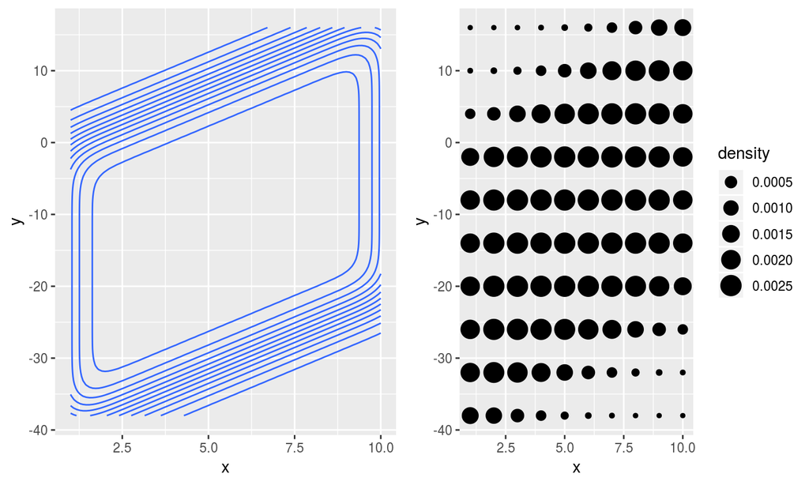

```r
> g1 <- ggplot(dat, aes(x, y)) + geom_density_2d()
> g2 <- ggplot(dat, aes(x, y)) +
+   stat_density_2d(geom = "point", n = 10, aes(size = stat(density)), contour = F)
> grid.arrange(g1, g2, ncol = 2)
```

## Common pitfalls of color use

- Color needs to be applied to serve a purpose.
  - It must be clear and must not distract.
- Use direct labeling instead of colors when you need to distinguish some points.
- Avoid large filled areas of overly saturated colors.
  - They make it difficult for your reader to carefully inspect your figure.
- Use monotonic colors for ordinary variables.
- Be thoughtful for color-vision deficiency.
- To make sure your figures work for people with cvd, don't just rely on specific color scales. Instead, test your figures in a cvd simulator.

## Redundant coding

- Whenever possible, design your figures so they don’t need a legend.

## Multi-panel figures

Small multiples

- Always arrange the panels in a small multiples plot in a meaningful and logical order.
- Use the same scale (`x` axis and `y` axis) throughout the small multiples

Compound figures

- Refer to with Fig xx.xx rather than top/left/bottom/right panel.
- lower case letters inside the figures
- Align figures
- Be coherent on content and colors

## Commonly used image file formats

Bitmap and vector graphics

- `pdf` (vector) is good for general purpose
- `png` (bitmap) is optimized for line drawings
- `jpeg` (bitmap) is optimized for photographic images

## Commonly used image file formats

- Vector graphics are "resolution-independent"
  - They can be magnified to arbitrary size without losing detail or sharpness.
- Vector graphics have downsides
  - Vector graphics are redrawn on the fly by the graphics program with which they are displayed
  - Can show differences in how the same graphic looks in two different programs, or on two different computers.
  - Large file sizes/slow to render for large/complex figures.

## Commonly used image file formats

- Most bitmap file formats employ some form of data compression to keep file sizes manageable.
- Could have side effects like blurry details.
- Converting between image formats – don't…